# Analysis of Ford GoBike System Data

## by oooo rrrr

## Investigation Overview

The most interesting part is to identify which stations are most overwhelmed with users and expreincing low or high number of bike-returns so that more investment and bike-transportation will be channeled. Which particular bikes were overused and need some repairment. And what day hours and weekdays bike-renting is most frequent, in what geo-positions bike-sharing business is most popular. Bike-riding popularity among genders and users as well as age groups. Furthermore, we can explore which station-to-station jurneys are most lucrative.

## Dataset Overview

In the dataset we have 183215 bike-lending records, which spans 28 days of February in 2019, in our dataset after preliminary cleaning, and 5 variables are categorical and 11 variables are numeric. Some columns that have unproper formats have been corrected. The structure is very well, except for member_gender which has some missing values and we can explore univariate, bivariate and multivariate relationships between bike trip duration, start time, geo-coordinates, start and end stations, user type, gender and their age. From the users' birth year we can calculate their age.

## Distribution of the bike trip durations

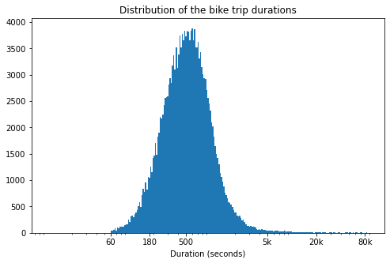

```python
log_binsize = 0.015
bins = 10 ** np.arange(1, np.log10(df['duration_sec'].max())+log_binsize, log_binsize)

plt.figure(figsize=[8, 5])
plt.hist(data = df, x = 'duration_sec', bins = bins)
plt.xscale('log')
plt.xticks([60, 180, 500, 5e3, 2e4, 8e4], [60, 180, 500, '5k', '20k', '80k'])
plt.xlabel('Duration (seconds)')
plt.title('Distribution of the bike trip durations')
plt.show()
```

## Distribution of what day hours and weekdays bike-renting is most frequent

Most bike trips occurs during the 9th and 18th hour of the day which are between 8.00 a.m. and 9 a.m. and between 17.00 p.m. and 18 p.m. respectively. During daytime bike trip frequencies are roughly equal while midtime it decreases significantly. Most popular week day for bike trips is Thursday while other weekdays it is slightly lower. However on weekends bike trips are twice as lower as weekdays.

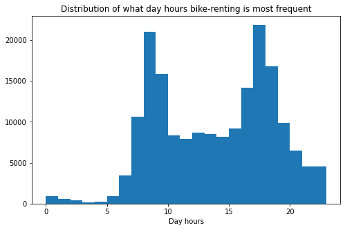

```python
# For that we add extra columns that extract daytimes and weekdays from start_time column:
df['dayhour'] = df['start_time'].dt.hour
df['weekday'] = df['start_time'].dt.day_name()

binsize = 1
bins = np.arange(0, 24, 1)

plt.figure(figsize=[8, 5])
plt.hist(data = df, x = 'dayhour', bins = bins)
plt.xlabel('Day hours')
plt.title('Distribution of what day hours bike-renting is most frequent')
plt.show()
```

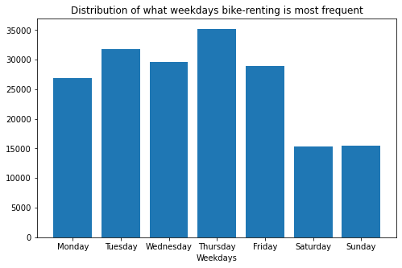

```python
# As for weekdays, first we count them and sort.
weekday_count = df.groupby('weekday').count()['start_time']\
[['Monday', 'Tuesday', 'Wednesday', 'Thursday', 'Friday', 'Saturday', 'Sunday']]

plt.figure(figsize=[8, 5])
plt.bar(x=weekday_count.index,
        height= weekday_count)
plt.xlabel('Weekdays')
plt.title('Distribution of what weekdays bike-renting is most frequent')
plt.show()
```

## Trip popularity among age groups

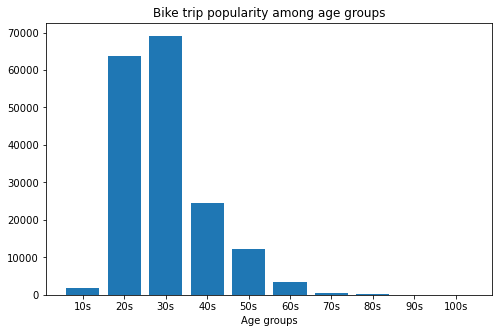

```python
#create age group column and plot bike trip distribution for age groups:
def spot_the_age_group(x):
    age = 2019 - x
    for i in np.arange(0, 110, 10):
        if (age >= i) and (age < i+10):
            return f'{i}s'

df['age_group'] = df['member_birth_year'].apply(spot_the_age_group)
df_age_groups = df['age_group'].value_counts().sort_index()
age_list = list(df_age_groups.index)
age_list = age_list[1:] + age_list[:1]
df_age_groups = df_age_groups.reindex(age_list)

#then we will plot the bike trip distribution among age groups
plt.figure(figsize=[8, 5])
plt.bar(x=df_age_groups.index,
        height= df_age_groups)
plt.xlabel('Age groups')
plt.title('Bike trip popularity among age groups')
plt.show()
```

## Top and outsider 20 stations with the number of bikes are inflowing and outflowing

We can say that stations 3, 6, 5, 15, 16, 21, 22, 30, 58, 67 and 81 are the top 11 stations that had most bike outflows and inflows, with 58 and 67 are championing in these regards respectively. The marketing department should pay an attention to this fact. In the meantime, the stations 67, 21, 15, 6, 44, 30, 3, 88, 182 are the top 9 stations that had stockpiled excess bikes and the stations 243, 253, 22, 71, 343, 256, 84, 81, 52 are the top 9 stations that experieced the shortage of bikes, with 67 and 243 extremelely high. Excess bikes shuold be transported to the stations falling short of enough bikes.

[figure not shown]

```python
#find how many bikes each station had lended altogether
start_stations = df.start_station_id.value_counts()
start_stations = pd.DataFrame(start_stations).reset_index().rename(columns={'index':'station_id','start_station_id':'bike_outflows'})

#find how many bikes each station had received altogether
end_stations = df.end_station_id.value_counts()
end_stations = pd.DataFrame(end_stations).reset_index().rename(columns={'index':'station_id','end_station_id':'bike_inflows'})

#join the two dataframes above:
df_bike_inflow_outflow = start_stations.set_index('station_id').join(end_stations.set_index('station_id'), how='outer')
df_bike_inflow_outflow['net_bike_inflows'] = df_bike_inflow_outflow['bike_inflows'] - df_bike_inflow_outflow['bike_outflows']
df_bike_inflow_outflow.reset_index(inplace=True)

#plot the 20 receiver, lender stations as well as the top 20 stations that are experiecing bike deficits or proficits
#at the end of the period.
sb.set_theme(style="whitegrid")
fig, ax = plt.subplots(nrows=4, figsize = [8,8], tight_layout=True)
data1=df_bike_inflow_outflow[['station_id', 'bike_outflows']].sort_values(by=['bike_outflows'], ascending=False).head(20)
data2=df_bike_inflow_outflow[['station_id', 'bike_inflows']].sort_values(by=['bike_inflows'], ascending=False).head(20)
data3=df_bike_inflow_outflow[['station_id', 'net_bike_inflows']].sort_values(by=['net_bike_inflows'], ascending=False).head(20)
data4=df_bike_inflow_outflow[['station_id', 'net_bike_inflows']].sort_values(by=['net_bike_inflows'], ascending=True).head(20)

default_color = sb.color_palette()[0]
red = sb.color_palette()[3]
sb.barplot(x="station_id", y="bike_outflows", data=data1, ax=ax[0], order=data1['station_id'], color=default_color)
sb.barplot(x="station_id", y="bike_inflows", data=data2, ax=ax[1], order=data2['station_id'], color=default_color)
sb.barplot(x="station_id", y="net_bike_inflows", data=data3, ax=ax[2], order=data3['station_id'], color=default_color)
sb.barplot(x="station_id", y="net_bike_inflows", data=data4, ax=ax[3], order=data4['station_id'], color=red)

ax[0].set_title('The top 20 stations with bike inflow numbers')
ax[1].set_title('The top 20 stations with bike outflow numbers')
ax[2].set_title('The top 20 stations with net bike inflow numbers')
ax[3].set_title('The most outsider 20 stations with net zero bike inflow numbers')
plt.show()
```

## Map of stations

The stations' locations are packed in three major areas with the two biggest relatively closer to each other.

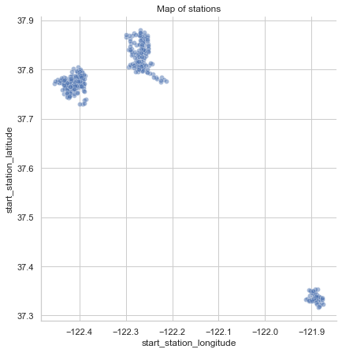

```python
#So the start_sation_id column gives all the station ids in out dataset. From that we derive the geopositions of the stations:

df_geo_locations = df[['start_station_id', 'start_station_latitude', 'start_station_longitude']].drop_duplicates()
df_geo_locations.reset_index(inplace=True, drop=True)
df_geo_locations = df_geo_locations[df_geo_locations.start_station_id !=0]

sb.relplot(x="start_station_longitude", y="start_station_latitude",
            sizes=(40, 400), alpha=.5, palette="muted",
            height=6, data=df_geo_locations)
plt.title('Map of stations')
plt.show()
```

## Overall durations per age group

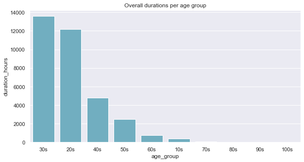

```python
# calculate overall durations per age group
df_overall_duration_per_agegroup = df[['age_group', 'duration_sec']].groupby('age_group').sum().reset_index()
df_overall_duration_per_agegroup.sort_values(by='duration_sec', ascending=False, inplace=True)
df_overall_duration_per_agegroup.reset_index(drop=True, inplace=True)
df_overall_duration_per_agegroup['duration_sec'] = df_overall_duration_per_agegroup['duration_sec'].apply(lambda x: x/3600)
df_overall_duration_per_agegroup.rename(columns={'duration_sec':'duration_hours'}, inplace=True)
data =df_overall_duration_per_agegroup

default_color = sb.color_palette()[9]
sb.set(rc = {'figure.figsize':(10,5)})
sb.barplot(x="age_group", y="duration_hours", data=data, color=default_color)
plt.title('Overall durations per age group')
plt.show()
```

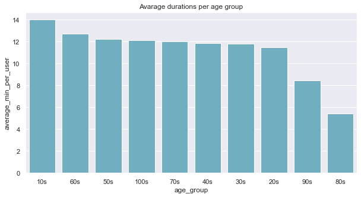

```python
#building a dataframe from the dataset, which contains age groups and average bike trip duration per user in age groups.
df_overall_duration_per_agegroup = df_overall_duration_per_agegroup\
.join(pd.DataFrame(df_age_groups), on='age_group', rsuffix='_number')
df_overall_duration_per_agegroup['average_min_per_user'] = df_overall_duration_per_agegroup.duration_hours*60/\
df_overall_duration_per_agegroup.age_group_number
df_overall_duration_per_agegroup

# calculate avarage durations per age group:
data = df_overall_duration_per_agegroup.sort_values(by='average_min_per_user', ascending=False)
default_color = sb.color_palette()[9]
sb.set(rc = {'figure.figsize':(10,5)})
sb.barplot(x="age_group", y="average_min_per_user", data=data, color=default_color)
plt.title('Avarage durations per age group')
plt.show()
```

## Overall durations per day

Overall trip durations per day fluctuated and peaked at the end of the period.

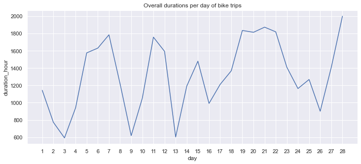

```python
# calculate overall durations of lended bikes per day:
df['day'] = df.end_time.dt.day
df['day_of_week'] = df.end_time.dt.day_name()
df_duration_per_day = df[['day', 'day_of_week', 'duration_sec']].groupby(['day', 'day_of_week']).sum().reset_index()
df_duration_per_day['duration_hour'] = df_duration_per_day['duration_sec'].apply(lambda x: x/3600)
df_duration_per_day

sb.set(rc = {'figure.figsize':(12,5)})
g = sb.lineplot(x="day", y="duration_hour", data=df_duration_per_day)
plt.xticks(df_duration_per_day.day)
plt.title('Overall durations per day of bike trips')

plt.show()
```

## Mapping the stations according to their geopositions

When we did bivariate exploration, we found that the stations are located cluster-like in three major areas. Now we will name the most north-western one, the most north-eastern one and the most south-eastern one A, B and C areas respectively. Accordingly, we will analyse end-of-the-period shortages and abundances of bikes and compare them on the map.

In all the three areas overall shortages and ubundancies of bikes are fairly balanced. Transportation can be done inside each area.

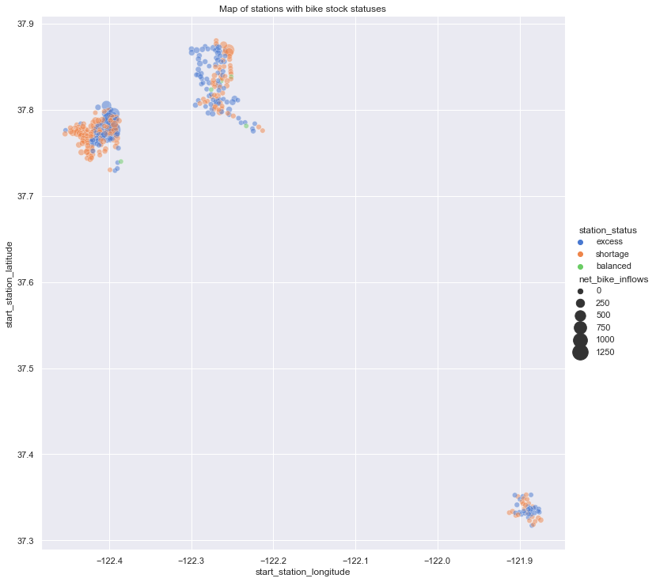

```python
# plotting the map of stations
sb.set(rc = {'figure.figsize':(100,100)})
sb.relplot(x="start_station_longitude", y="start_station_latitude", hue="station_status", size="net_bike_inflows",
            sizes=(40, 400), alpha=.5, palette="muted",
            height=10, data=df_map)
plt.title('Map of stations with bike stock statuses')
plt.show()
```

Let's zoom in to look at from which station to which station bikes should be transported:

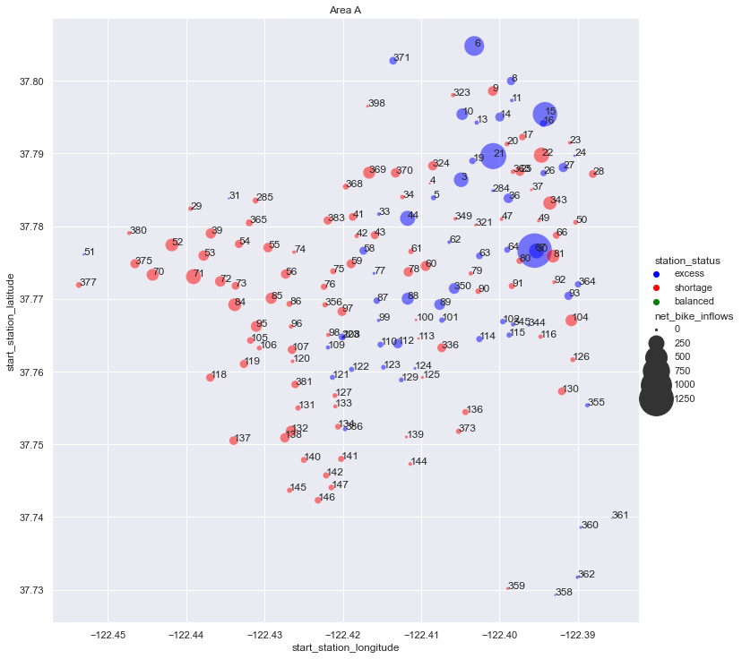

```python
#plotting the map of area A
hue_order = ["excess", "shortage", "balanced"]
ax = sb.set(rc = {'figure.figsize':(100,100)})
sb.relplot(x="start_station_longitude", y="start_station_latitude", hue="station_status", hue_order=hue_order,\
           size="net_bike_inflows",
            sizes=(5, 1500), alpha=.5, palette=['blue', 'red', 'green'],
            height=10, data=df_map_A)

label_point(df_map_A.start_station_longitude, df_map_A.start_station_latitude, df_map_A.station_id, plt.gca())
plt.title('Area A')
plt.show()
```

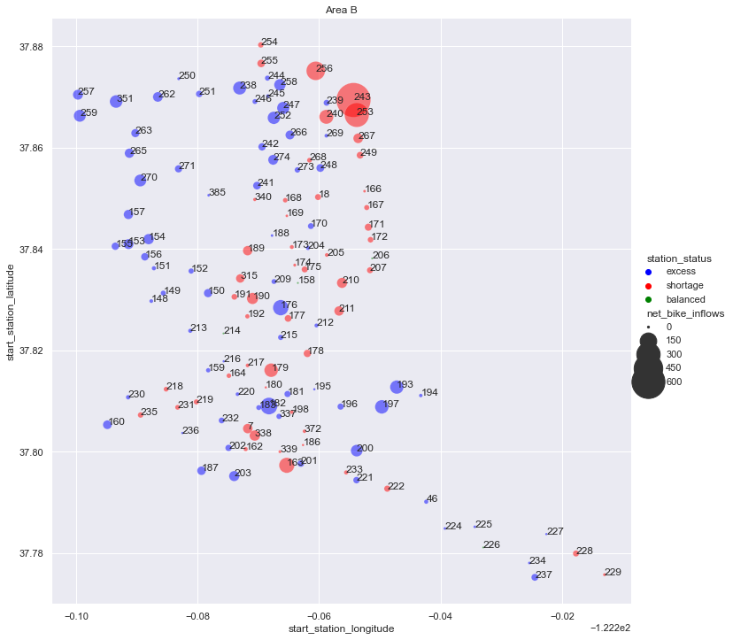

```python
#plotting the map of area B
ax = sb.set(rc = {'figure.figsize':(100,100)})
sb.relplot(x="start_station_longitude", y="start_station_latitude", hue="station_status", hue_order=hue_order,\
           size="net_bike_inflows",
            sizes=(5, 1500), alpha=.5, palette=['blue', 'red', 'green'],
            height=10, data=df_map_B)

label_point(df_map_B.start_station_longitude, df_map_B.start_station_latitude, df_map_B.station_id, plt.gca())
plt.title('Area B')
plt.show()
```

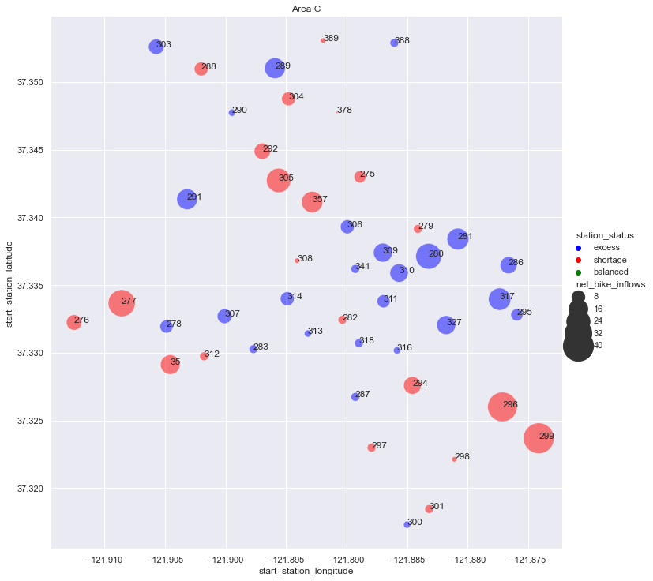

```python
#plotting the map of area C
x = sb.set(rc = {'figure.figsize':(100,100)})
sb.relplot(x="start_station_longitude", y="start_station_latitude", hue="station_status", hue_order=hue_order,\
           size="net_bike_inflows",
            sizes=(5, 1500), alpha=.5, palette=['blue', 'red', 'green'],
            height=10, data=df_map_C)

label_point(df_map_C.start_station_longitude, df_map_C.start_station_latitude, df_map_C.station_id, plt.gca())
plt.title('Area C')
plt.show()
```

```python
!jupyter nbconvert Project_lend_bikes_Part2.ipynb --to slides --post serve --no-input --no-prompt
```

```
^C
```